# Longitudinal analysis

Suvi Virtanen

4 joulukuuta 2018

# Analysis of longitudinal data

**Analysis of Longitudinal Data I: Graphical Displays and Summary Measure Approach**

```r
library(ggplot2)
library(dplyr)
library(GGally)
library(MASS)
library(tidyr)
library(boot)
library(corrplot)
library(lme4)

RATSL <- read.csv("ratsl.csv", header = T)
BPRSL <- read.csv("bprsl.csv", header = T)
```

Let’s take a look at the RATS data:

```r
RATSL$ID <- factor(RATSL$ID)
RATSL$Group <- factor(RATSL$Group)
summary(RATSL)
```

```
##        X                ID      Group        WD         Weight
##  Min.   :  1.00   1      : 11   1:88   WD1    :16   Min.   :225.0
##  1st Qu.: 44.75   2      : 11   2:44   WD15   :16   1st Qu.:267.0
##  Median : 88.50   3      : 11   3:44   WD22   :16   Median :344.5
##  Mean   : 88.50   4      : 11          WD29   :16   Mean   :384.5
##  3rd Qu.:132.25   5      : 11          WD36   :16   3rd Qu.:511.2
##  Max.   :176.00   6      : 11          WD43   :16   Max.   :628.0
##                   (Other):110          (Other):80
##       Time         stdweight
##  Min.   : 1.00   Min.   :-2.82850
##  1st Qu.:15.00   1st Qu.:-0.63677
##  Median :36.00   Median : 0.09381
##  Mean   :33.55   Mean   : 0.00000
##  3rd Qu.:50.00   3rd Qu.: 0.74509
##  Max.   :64.00   Max.   : 2.19240
##
```

```r
str(RATSL)
```

```
## 'data.frame':    176 obs. of  7 variables:
##  $ X        : int  1 2 3 4 5 6 7 8 9 10 ...
##  $ ID       : Factor w/ 16 levels "1","2","3","4",..: 1 2 3 4 5 6 7 8 9 10 ...
##  $ Group    : Factor w/ 3 levels "1","2","3": 1 1 1 1 1 1 1 1 2 2 ...
##  $ WD       : Factor w/ 11 levels "WD1","WD15","WD22",..: 1 1 1 1 1 1 1 1 1 1 ...
##  $ Weight   : int  240 225 245 260 255 260 275 245 410 405 ...
##  $ Time     : int  1 1 1 1 1 1 1 1 1 1 ...
##  $ stdweight: num  -1.733 -2.829 -1.367 -0.271 -0.637 ...
```

Plotting individuals growth curves for individual rats in the RATSL data

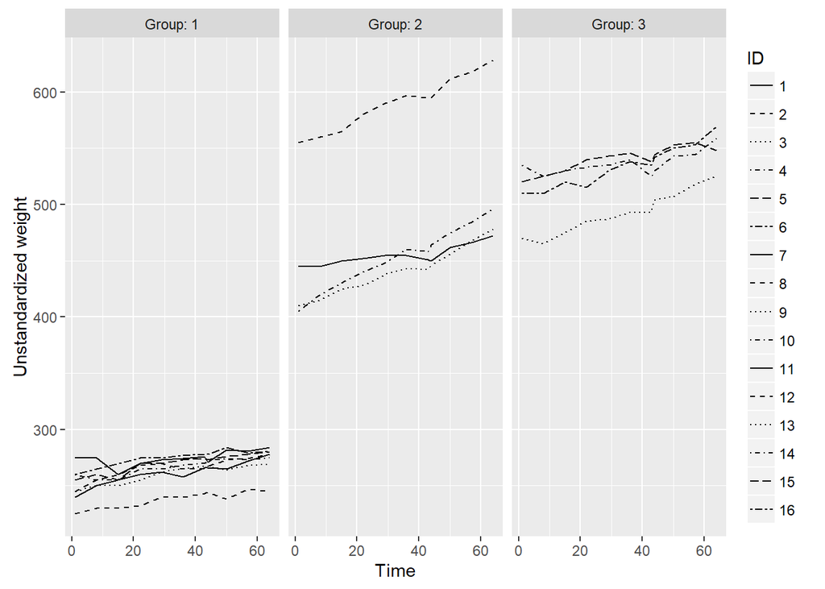

```r
ggplot(RATSL, aes(x = Time, y = Weight, linetype = ID)) +
  geom_line() +
  scale_linetype_manual(values = rep(1:10, times=4)) +
  facet_grid(. ~ Group, labeller = label_both) +
  scale_y_continuous(name = "Unstandardized weight")
```

Rats in group 1 develop similarly over time (ie. growth is slow), there is some variability within the group. Rats in groups 2 and 3 gain more weight, and start from a higher weight level as compared to group 1. There are also substantial individual differences within these groups.

```r
# Standardise the variable Weight
RATSL <- RATSL %>%
  group_by(Group) %>%
  mutate(stdweight = (Weight - mean(Weight))/sd(Weight) ) %>%
  ungroup()

glimpse(RATSL)
```

```
## Observations: 176
## Variables: 7
## $ X         (int) 1, 2, 3, 4, 5, 6, 7, 8, 9, 10, 11, 12, 13, 14, 15, 1...
## $ ID        (fctr) 1, 2, 3, 4, 5, 6, 7, 8, 9, 10, 11, 12, 13, 14, 15, ...
## $ Group     (fctr) 1, 1, 1, 1, 1, 1, 1, 1, 2, 2, 2, 2, 3, 3, 3, 3, 1, ...
## $ WD        (fctr) WD1, WD1, WD1, WD1, WD1, WD1, WD1, WD1, WD1, WD1, W...
## $ Weight    (int) 240, 225, 245, 260, 255, 260, 275, 245, 410, 405, 44...
## $ Time      (int) 1, 1, 1, 1, 1, 1, 1, 1, 1, 1, 1, 1, 1, 1, 1, 1, 8, 8...
## $ stdweight (dbl) -1.73263452, -2.82850303, -1.36734502, -0.27147652, ...
```

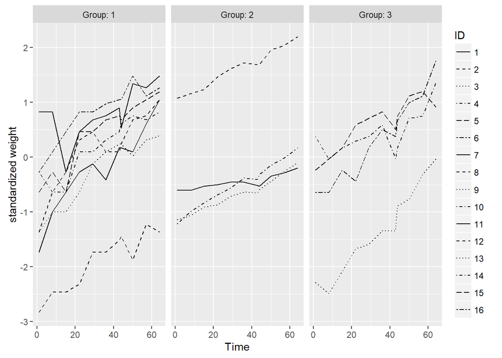

```r
# Plot again with the standardised weight

ggplot(RATSL, aes(x = Time, y = stdweight, linetype = ID)) +
  geom_line() +
  scale_linetype_manual(values = rep(1:10, times=4)) +
  facet_grid(. ~ Group, labeller = label_both) +
  scale_y_continuous(name = "standardized weight")
```

The large within and between group variablility in growth curves and starting points in weight can be seen very clearly in these standardized plots as well.

```r
# Number of weeks, baseline (week 0) included
n <- RATSL$Time %>% unique() %>% length()

# Summary data with mean and standard error of rats by Group and Week
RATSS <- RATSL %>%
  group_by(Group, Time) %>%
  summarise( mean = mean(Weight), se = sd(Weight)/sqrt(n) ) %>%
  ungroup()

# Glimpse the data
glimpse(RATSS)
```

```
## Observations: 33
## Variables: 4
## $ Group (fctr) 1, 1, 1, 1, 1, 1, 1, 1, 1, 1, 1, 2, 2, 2, 2, 2, 2, 2, 2...
## $ Time  (int) 1, 8, 15, 22, 29, 36, 43, 44, 50, 57, 64, 1, 8, 15, 22, ...
## $ mean  (dbl) 250.625, 255.000, 254.375, 261.875, 264.625, 265.000, 26...
## $ se    (dbl) 4.589478, 3.947710, 3.460116, 4.100800, 3.333956, 3.5529...
```

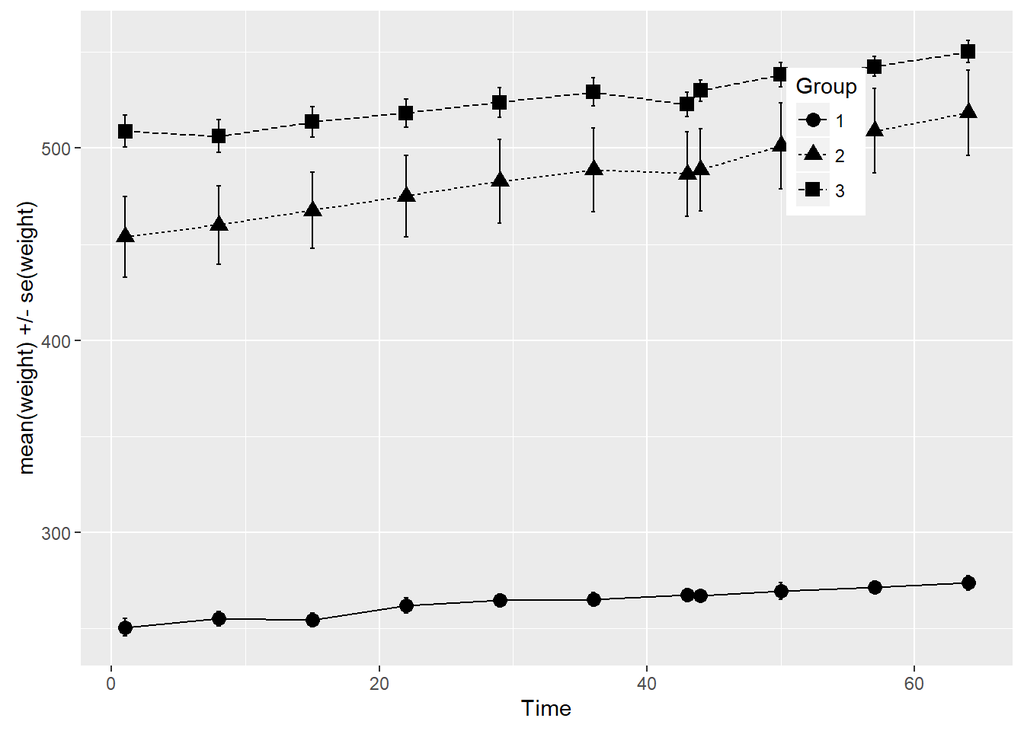

```r
# Plot the mean profiles
ggplot(RATSS, aes(x = Time, y = mean, linetype = Group, shape = Group)) +
  geom_line() +
  geom_point(size=3) +
  geom_errorbar(aes(ymin = mean - se, ymax = mean + se, linetype="1"), width=0.3) +
  theme(legend.position = c(0.8,0.8)) +
  scale_y_continuous(name = "mean(weight) +/- se(weight)")
```

```r
# Create a summary data by treatment and subject with mean as the summary variable.
RATSL8S <- RATSL %>%
  group_by(Group, ID) %>%
  summarise( mean=mean(Weight) ) %>%
  ungroup()

# Glimpse the data
glimpse(RATSL8S)
```

```
## Observations: 16
## Variables: 3
## $ Group (fctr) 1, 1, 1, 1, 1, 1, 1, 1, 2, 2, 2, 2, 3, 3, 3, 3
## $ ID    (fctr) 1, 2, 3, 4, 5, 6, 7, 8, 9, 10, 11, 12, 13, 14, 15, 16
## $ mean  (dbl) 261.0909, 237.6364, 260.1818, 266.5455, 269.4545, 274.72...
```

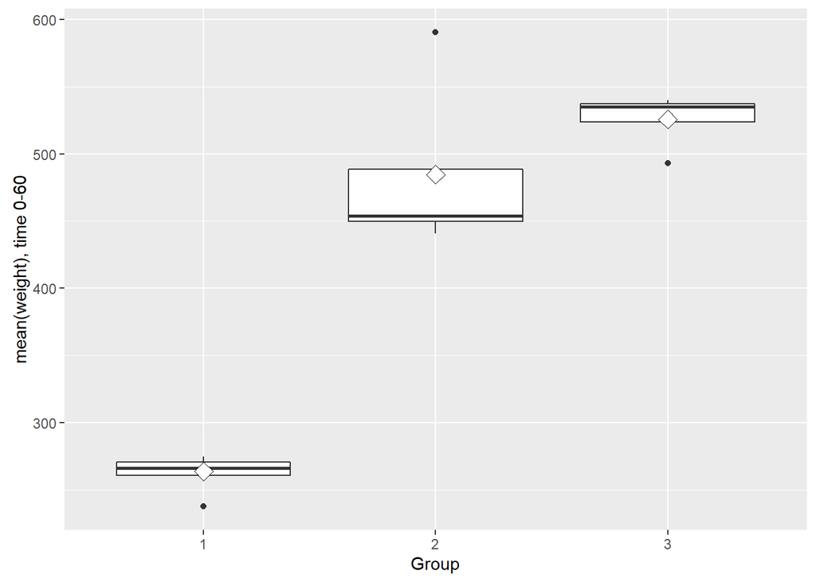

```r
# Draw a boxplot of the mean versus group
ggplot(RATSL8S, aes(x = Group, y = mean)) +
  geom_boxplot() +
  stat_summary(fun.y = "mean", geom = "point", shape=23, size=4, fill = "white") +
  scale_y_continuous(name = "mean(weight), time 0-60")
```

Illustration of mean weight in different groups of rats. Group 1 has the lowest mean weight. Group 3 has the largest. Group 2 has the largest variance.

```r
# Confirming statistical significance of mean differences with ANOVA
model <- lm(data=RATSL8S, mean ~ Group)
anova(model)
```

```
## Analysis of Variance Table
##
## Response: mean
##           Df Sum Sq Mean Sq F value    Pr(>F)
## Group      2 236732  118366  88.073 2.763e-08 ***
## Residuals 13  17471    1344
## ---
## Signif. codes:  0 '***' 0.001 '**' 0.01 '*' 0.05 '.' 0.1 ' ' 1
```

**Analysis of Longitudinal Data II: Linear Mixed Effects Models for Normal Response Variables**

Now, we are switching to the BPRL data:

```r
BPRSL$treatment <- factor(BPRSL$treatment)
BPRSL$subject <- factor(BPRSL$subject)
glimpse(BPRSL)
```

```
## Observations: 360
## Variables: 6
## $ X         (int) 1, 2, 3, 4, 5, 6, 7, 8, 9, 10, 11, 12, 13, 14, 15, 1...
## $ treatment (fctr) 1, 1, 1, 1, 1, 1, 1, 1, 1, 1, 1, 1, 1, 1, 1, 1, 1, ...
## $ subject   (fctr) 1, 2, 3, 4, 5, 6, 7, 8, 9, 10, 11, 12, 13, 14, 15, ...
## $ weeks     (fctr) week0, week0, week0, week0, week0, week0, week0, we...
## $ bprs      (int) 42, 58, 54, 55, 72, 48, 71, 30, 41, 57, 30, 55, 36, ...
## $ week      (int) 0, 0, 0, 0, 0, 0, 0, 0, 0, 0, 0, 0, 0, 0, 0, 0, 0, 0...
```

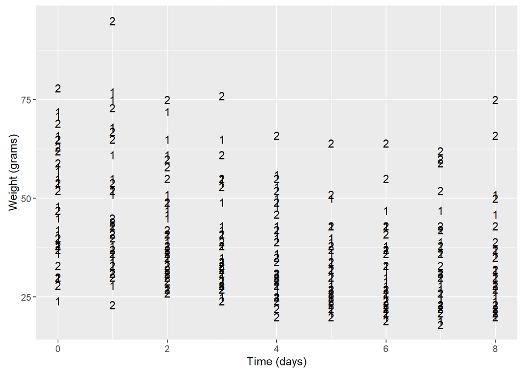

```r
# Plot of symptoms against time, ignoring the repeated-measures structure of the data but identifying the group to which each observation belongs.

ggplot(BPRSL, aes(x = week, y = bprs)) + geom_text(aes(linetype = treatment, label = treatment)) + scale_x_continuous(name = "Time (days)") + scale_y_continuous(name = "Weight (grams)") + theme(legend.position = "top")
```

```r
# Linear regression: ignoring the lognitudinal nature of the data

# create a regression model BPRS_reg
BPRS_reg <- lm(data = BPRSL, bprs ~ week + treatment + week*treatment)

# print out a summary of the model
summary(BPRS_reg)
```

```
##
## Call:
## lm(formula = bprs ~ week + treatment + week * treatment, data = BPRSL)
##
## Residuals:
##     Min      1Q  Median      3Q     Max
## -23.886  -9.267  -2.801   6.513  51.318
##
## Coefficients:
##                 Estimate Std. Error t value Pr(>|t|)
## (Intercept)      47.8856     1.6970  28.218  < 2e-16 ***
## week             -2.6283     0.3564  -7.374 1.17e-12 ***
## treatment2       -2.2911     2.3999  -0.955    0.340
## week:treatment2   0.7158     0.5041   1.420    0.156
## ---
## Signif. codes:  0 '***' 0.001 '**' 0.01 '*' 0.05 '.' 0.1 ' ' 1
##
## Residual standard error: 12.35 on 356 degrees of freedom
## Multiple R-squared:  0.1897, Adjusted R-squared:  0.1829
## F-statistic: 27.78 on 3 and 356 DF,  p-value: 3.629e-16
```

Looks like only week (time) had statistically significant effect on the symptoms. In other words, it did not seem to matter if the subject was in the treatment of the control group, their symptoms - on averge - were reduced either way. Also, the week-by-treatment interaction not being significant implicates that the effect of time on symptoms was not dependent on which group the subject belonged to.

Next, let’s move on to inspecting the data longitudinally.

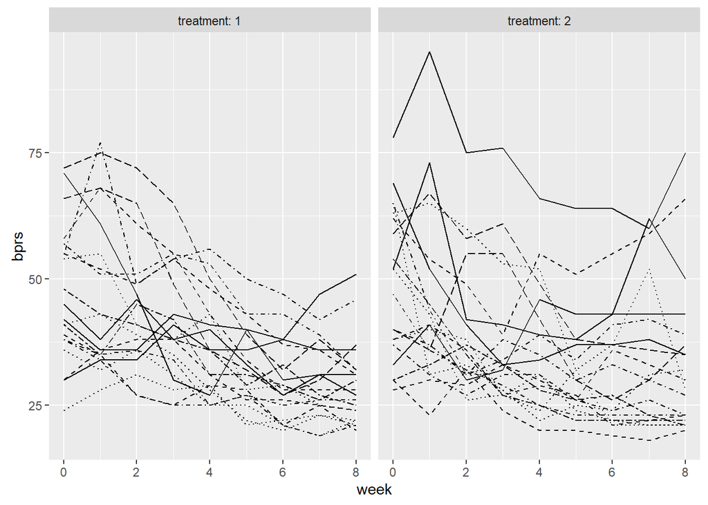

```r
# Draw the plot
ggplot(BPRSL, aes(x = week, y = bprs, linetype = subject)) +
  geom_line() +
  scale_linetype_manual(values = rep(1:10, times=4)) +
  facet_grid(. ~ treatment, labeller = label_both) +
  theme(legend.position = "none") +
  scale_y_continuous(limits = c(min(BPRSL$bprs), max(BPRSL$bprs)))
```

Plots show individual variation in BPRS scores over the 8-week intervention period in the treatment and control groups. It is not very informative, as the variability is very high in both groups.

Next up, longitudinal modeling:

```r
# Create a random intercept model
BPRS_ref <- lmer(bprs ~ week + treatment + (1 | subject), data = BPRSL, REML = FALSE)

summary(BPRS_ref)
```

```
## Linear mixed model fit by maximum likelihood  ['lmerMod']
## Formula: bprs ~ week + treatment + (1 | subject)
##    Data: BPRSL
##
##      AIC      BIC   logLik deviance df.resid
##   2748.7   2768.1  -1369.4   2738.7      355
##
## Scaled residuals:
##     Min      1Q  Median      3Q     Max
## -3.0481 -0.6749 -0.1361  0.4813  3.4855
##
## Random effects:
##  Groups   Name        Variance Std.Dev.
##  subject  (Intercept)  47.41    6.885
##  Residual             104.21   10.208
## Number of obs: 360, groups:  subject, 20
##
## Fixed effects:
##             Estimate Std. Error t value
## (Intercept)  46.4539     1.9090  24.334
## week         -2.2704     0.2084 -10.896
## treatment2    0.5722     1.0761   0.532
##
## Correlation of Fixed Effects:
##            (Intr) week
## week       -0.437
## treatment2 -0.282  0.000
```

In this model, we have allowed intercepts to vary by study subject. Random effects suject variance is quite large, so it seems that this was a good decision. There is decrease in symptoms over time, but treatment vs. control group has no significant effect.

```r
# create a random intercept and random slope model
BPRS_ref1 <- lmer(bprs ~ week + treatment + (week | subject), data = BPRSL, REML = FALSE)

# print a summary of the model
summary(BPRS_ref1)
```

```
## Linear mixed model fit by maximum likelihood  ['lmerMod']
## Formula: bprs ~ week + treatment + (week | subject)
##    Data: BPRSL
##
##      AIC      BIC   logLik deviance df.resid
##   2745.4   2772.6  -1365.7   2731.4      353
##
## Scaled residuals:
##     Min      1Q  Median      3Q     Max
## -2.8919 -0.6194 -0.0691  0.5531  3.7976
##
## Random effects:
##  Groups   Name        Variance Std.Dev. Corr
##  subject  (Intercept) 64.8202  8.0511
##           week         0.9608  0.9802   -0.51
##  Residual             97.4307  9.8707
## Number of obs: 360, groups:  subject, 20
##
## Fixed effects:
##             Estimate Std. Error t value
## (Intercept)  46.4539     2.1052  22.066
## week         -2.2704     0.2977  -7.626
## treatment2    0.5722     1.0405   0.550
##
## Correlation of Fixed Effects:
##            (Intr) week
## week       -0.582
## treatment2 -0.247  0.000
```

Now, adding random slope also allows for the growth curves to vary between individuals. There is variance in random slopes as well.

```r
# perform an ANOVA test on the two models
anova(BPRS_ref1, BPRS_ref)
```

```
## Data: BPRSL
## Models:
## BPRS_ref: bprs ~ week + treatment + (1 | subject)
## BPRS_ref1: bprs ~ week + treatment + (week | subject)
##           Df    AIC    BIC  logLik deviance  Chisq Chi Df Pr(>Chisq)
## BPRS_ref   5 2748.7 2768.1 -1369.4   2738.7
## BPRS_ref1  7 2745.4 2772.6 -1365.7   2731.4 7.2721      2    0.02636 *
## ---
## Signif. codes:  0 '***' 0.001 '**' 0.01 '*' 0.05 '.' 0.1 ' ' 1
```

With ANOVA, we can compare these two models with one another. Lower BIC and AIC values indicate that the model has better fit with the data. Model with random intercept and slope has sightly better fit, as indicated by the p-value < .05.

```r
# create a random intercept and random slope model with the interaction
BPRS_ref2 <- lmer(bprs ~ week + treatment + week * treatment + (week | subject), data = BPRSL, REML = FALSE)

# print a summary of the model
summary(BPRS_ref2)
```

```
## Linear mixed model fit by maximum likelihood  ['lmerMod']
## Formula: bprs ~ week + treatment + week * treatment + (week | subject)
##    Data: BPRSL
##
##      AIC      BIC   logLik deviance df.resid
##   2744.3   2775.4  -1364.1   2728.3      352
##
## Scaled residuals:
##     Min      1Q  Median      3Q     Max
## -3.0512 -0.6271 -0.0767  0.5288  3.9260
##
## Random effects:
##  Groups   Name        Variance Std.Dev. Corr
##  subject  (Intercept) 65.0016  8.0624
##           week         0.9688  0.9843   -0.51
##  Residual             96.4699  9.8219
## Number of obs: 360, groups:  subject, 20
##
## Fixed effects:
##                 Estimate Std. Error t value
## (Intercept)      47.8856     2.2522  21.262
## week             -2.6283     0.3589  -7.323
## treatment2       -2.2911     1.9090  -1.200
## week:treatment2   0.7158     0.4010   1.785
##
## Correlation of Fixed Effects:
##             (Intr) week   trtmn2
## week        -0.650
## treatment2  -0.424  0.469
## wek:trtmnt2  0.356 -0.559 -0.840
```

```r
# perform an ANOVA test on the two models
anova(BPRS_ref2, BPRS_ref1)
```

```
## Data: BPRSL
## Models:
## BPRS_ref1: bprs ~ week + treatment + (week | subject)
## BPRS_ref2: bprs ~ week + treatment + week * treatment + (week | subject)
##           Df    AIC    BIC  logLik deviance  Chisq Chi Df Pr(>Chisq)
## BPRS_ref1  7 2745.4 2772.6 -1365.7   2731.4
## BPRS_ref2  8 2744.3 2775.4 -1364.1   2728.3 3.1712      1    0.07495 .
## ---
## Signif. codes:  0 '***' 0.001 '**' 0.01 '*' 0.05 '.' 0.1 ' ' 1
```

Adding a interaction term between time and treatment group did not reach significance, nor did it significantly improve the model. In other words, the effect of time on symptoms was not dependent on which group the subject belonged to. Thus, it can be left out because the simpler model is preferred in case the model fit is the similar.

```r
# Create a vector of the fitted values
Fitted <- fitted(BPRS_ref1)

# Create a new column fitted to bprSL
mutate(BPRSL, Fitted = Fitted)
```

[output not shown]

[output cut: 346 more lines]

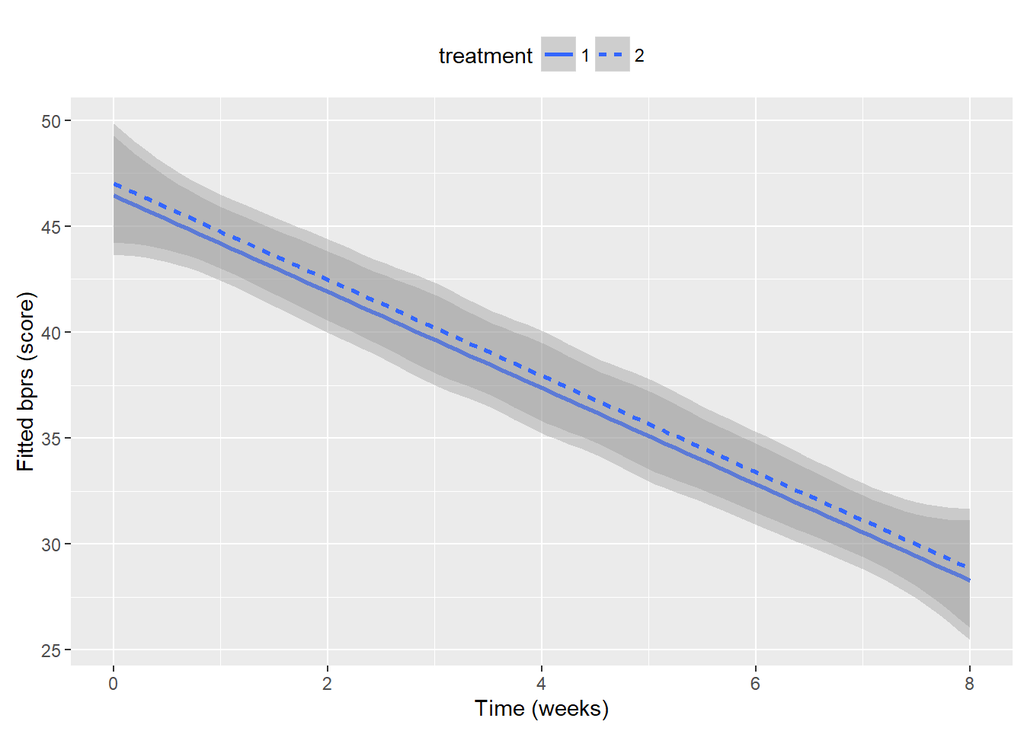

```r
# draw the plot of BPRSL with the Fitted values of symptoms
ggplot(BPRSL, aes(x = week, y = Fitted, group = treatment)) +
  geom_smooth(aes(linetype = treatment)) +
  scale_x_continuous(name = "Time (weeks)") +
  scale_y_continuous(name = "Fitted bprs (score)") +
  theme(legend.position = "top")
```

The above figure shows plot of fitted values in both treatment and control groups. They appear to have very similar trajectories.